# Aside

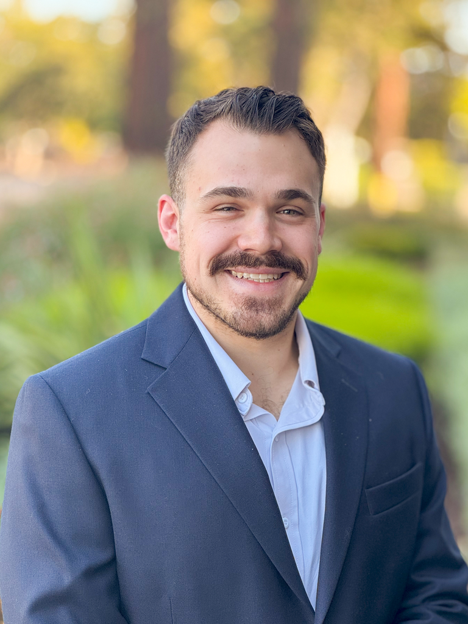

## Contact

- aaronmgraifman@gmail.com
- linkedin.com/in/aaron-graifman
- github.com/aaron13g

## Language Skills

R

Python

C++

Tableau

## Disclaimer

Made w/ [**pagedown**](https://github.com/rstudio/pagedown).

Source code: github.com/nstrayer/cv.

Last updated on 2026-02-23.

# Main

## Aaron Graifman

Graduate student in Program Evaluation and Data Analytics working in a public sector data environment. I develop dashboards and visualizations in Tableau and conduct ad hoc analyses using administrative program data to support operational and policy questions.

My work focuses on clear communication of findings and translating data into actionable insight. I am continuing to expand my skills in R and applied statistical methods.

## Education

### M.S. Program Evaluation and Data Analytics

Tempe, AZ

Arizona State University

2026 - 2024

- Graduate coursework in program evaluation, statistical modeling, and applied data science.
- Focus on public sector analytics and evidence-based decision support.
- Expected 2026

### B.S. Data Science

Tempe, AZ

Arizona State University

2024 - 2023

- Undergraduate training in statistical analysis, programming, and data systems.
- Emphasis on quantitative reasoning and applied analytics.

### A.S. Mathematics

Pleasant Hill, CA

Diablo Valley College

2022 - 2020

- Associate degree focused on advanced mathematics and quantitative methods.

## Selected Positions

### Planner / Evaluator

Concord, CA

Contra Costa County Employment & Human Services Department

Present - 2025

- Develop evaluation questions, measures, dashboards, and written findings for county human services initiatives.
- Analyze administrative program data in Tableau, R, and Excel to support planning, monitoring, and policy decisions.
- Produce time-sensitive analyses and Board materials, including work supporting a $21M CalFresh backfill request.

### Quizmaster

Walnut Creek, CA

King Trivia

Present - 2023

- Facilitate live trivia events, ensuring clear communication and smooth execution.
- Manage timing, resolve disputes, and engage diverse audiences professionally.

### Fitness Manager

Pleasanton, CA

Vim + Vigor Fitness

2025 - 2024

- Managed operations for high-volume personal training department and supervised staff.
- Tracked KPIs including retention, utilization, and sales; improved structured data collection processes.
- Communicated performance insights to leadership.

### Personal Trainer

Concord, CA

Vim + Vigor Fitness / Fitness 19

2024 - 2023

- Designed individualized programs and tracked client performance metrics.
- Collected and analyzed biometric and session data to guide program adjustments.

### Data Analytics Intern

Phoenix, AZ

Arizona State University

2024

- Cleaned and validated datasets to improve data quality for decision-making.
- Documented changes and communicated findings to support team planning.

### Physics Tutor

Pleasant Hill, CA

Diablo Valley College

2022 - 2020

- Provided individualized academic support in physics and quantitative reasoning.
- Adapted teaching approaches to meet diverse learning styles.

## Selected Professional Projects

### Multi-Program Cluster Analysis

Concord, CA

Contra Costa County EHSD

2026

- Conducted cluster analysis of EHSD participants to identify multi-program participation patterns.
- Partnered with executive leadership to refine findings for presentation and decision-making.
- Final analysis was used in the Annual Budget Presentation to the Board of Supervisors.

### Empowering Enrollment Dashboard

Concord, CA

Contra Costa County EHSD

2025

- Designed and built a Tableau dashboard to support CalFresh outreach planning and enrollment strategy.
- Mapped participation patterns to identify target populations and service opportunities.
- Presented findings to staff and community partners to support monitoring and iteration.

## Academic Projects

### CalFresh Evaluation Design (Graduate Project)

Tempe, AZ

Arizona State University

2025

- Designed an evaluation framework including logic model, indicators, and data sources for CalFresh enrollment strategy.
- Researched feasibility constraints and implementation considerations using public program documentation.
- Produced written evaluation plan and presentation for graduate coursework.

### CDC Diabetes Indicators Analysis (Capstone Project)

Tempe, AZ

Arizona State University

2024

- Analyzed CDC Diabetes Indicators dataset using Python and SQL to identify patterns in health outcomes.
- Applied basic machine learning techniques to explore predictive relationships.
- Presented findings and recommendations to faculty panel.